# Results of Kannunvalajat study questionnaire

Riku Laine  
10.1.2018

[figure not shown]

### Contents

- The data in brief
- Results by theme
- Some notes

**Themes:**

- *Marketing*
- *Choosing the branch of studies*
- *Planning and progression of studies*
- *Courses*
- *Teaching*
- *General opinions towards the reform*
- *Correspondence tables*
- *Communication of the reform*
- *Study counselling*
- *Student representatives*

### The data in brief (1/2)

- The data is the result of a student questionnaire held in November.
- A total of 313 respondents of which
  - 117 study by the current curriculum
  - 193 study by the old curriculum
- Also three students studying by the current curricula answered in English.

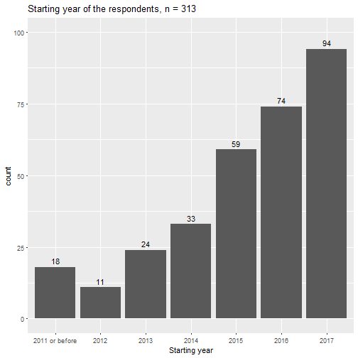

### The data in brief (2/2)

- The questionnaire consisted of 34 or 37 questions depending on the respondent's curriculum.
- Most of the questions were answered in the 5-point [Likert scale](https://en.wikipedia.org/wiki/Likert_scale).
  - Open-ended questions were removed
  - *1 = Strongly disagree*
  - *5 = Strongly agree*

| Program/Subject | Frequency |
| --- | --- |
| Sosiaalitieteiden kandiohjelma | 41 |
| Yleinen valtio-oppi | 29 |
| Politiikka ja viestintä | 28 |
| Viestintä | 25 |
| Sosiologia | 20 |
| Poliittinen historia | 19 |
| Yhteiskuntapolitiikka | 18 |
| Sosiaalipsykologia | 17 |
| Sosiaali- ja kulttuuriantropologia | 14 |
| Sosiaalitieteiden maisteriohjelma | 14 |

### Marketing

- Names of the new programs have been quite descriptive, mean of the answers was \( \approx \) 4.25.
- Marketing hasn't been that successful as one in three respondents (33.3%) claimed they couldn't find info easily.

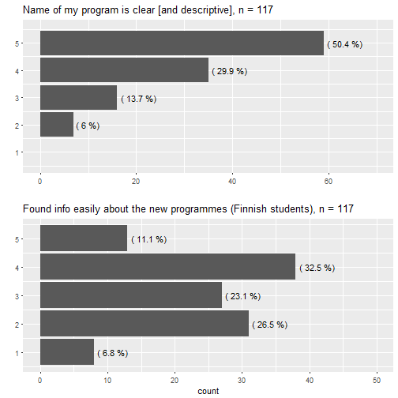

### Choosing the branch of studies

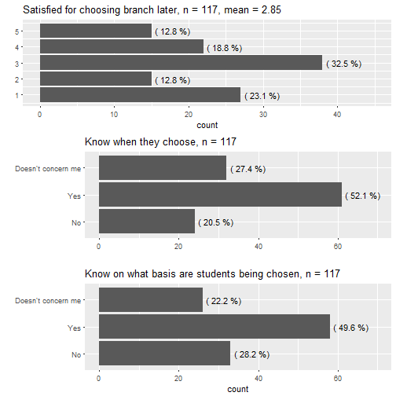

### Planning and progress of studies

- Almost two in five (39%) claimed their studies had not proceeded without disturbance.
- Nearly half of the students have experienced that planning their studies has not been smooth.

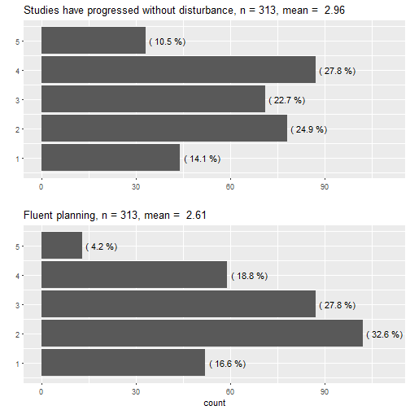

### Courses - practices

- Almost half think the reform has affected the amount of mandatory presence and supply of alternative ways to pass courses (essays etc.). *(NB the amount of Don't knows)*
- Students have pretty much liked methods and contents.
- 60% weren't satisfied with the new courses and programs (compared to the previous years).

| Has.reform.affected | Yes | No | DK |
| --- | --- | --- | --- |
| Mandatory presence | 43.5 | 22.3 | 34.2 |
| Alternative examining | 49.7 | 7.3 | 43.0 |

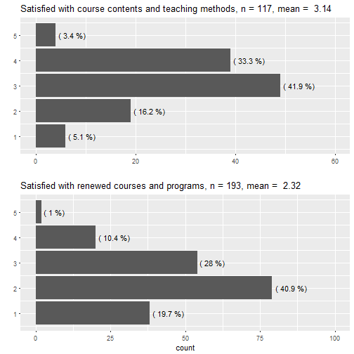

### Courses - attending

- One in five couldn't have attended the courses of the new programs that belong to their major studies.
- Roughly twice larger a portion is not able to participate in their minor subject's courses.

**I am able to attend the courses that belong to my […] studies.** (n = 193, in %)

|  | No | Yes |
| --- | --- | --- |
| Major | 21.2 | 78.8 |
| Minor | 37.8 | 62.2 |

### Teaching

- New students are quite satisfied with the quality of teaching, more than half agreed or strongly agreed.
- Some of the old students feel that the quality of teaching has decreased, though the distribution of answers is quite symmetrical.

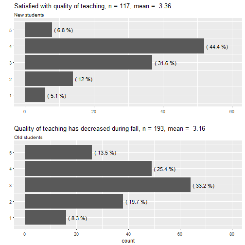

### General opinions

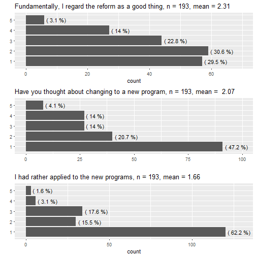

- The Big Wheel is not well appreciated among students per se.
- Some students have thought about changing to a new program, but majority want to stick with the old
- No regret noticeable, almost no one had rather applied to a new program

### Correspondence tables (CT)

- Clarity of especially minor subjects' correspondence tables should be improved.
- Students seem to have a hard time finding their minors' correspondence tables.

*n = 193*

|  | No | Yes |
| --- | --- | --- |
| Major's CTs are clear | 28.5 | 71.5 |
| Minor's CTs are clear | 64.8 | 35.2 |
| Know where are major's CTs | 8.8 | 91.2 |
| Know where are minor's CTs | 52.3 | 47.7 |

### Communication of the reform

- Information concerning the Big Wheel has been hard to find and insufficient.
  - Over half of the respondents disagreed or strongly disagreed to both of the claims.

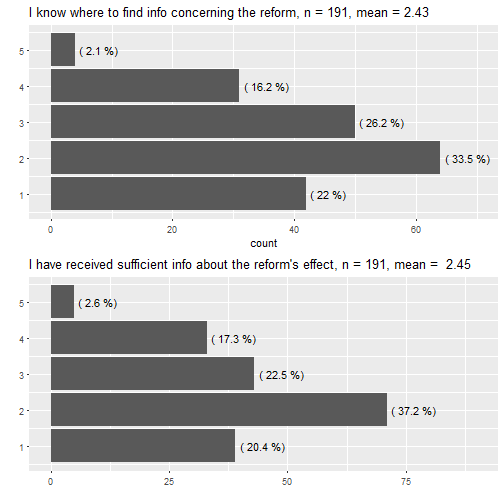

### Study counselling

- There is room for improvement as half of the students think their questions have been left unanswered.

**I have received help in problem situations concerning my studies.**

(n = 310)

| No | Yes | I haven't had issues |
| --- | --- | --- |
| 29 | 47.7 | 23.2 |

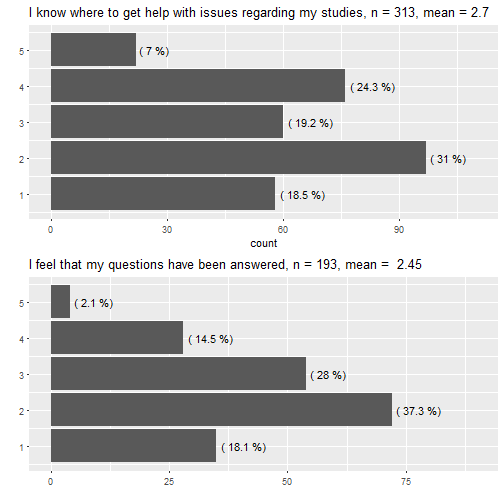

### Student representatives

- Study representatives *(opintovastaavat)* are known by every three in five students.
- Students don't know the student representatives of their programs' executive groups *(johtoryhmien opiskelijaedustajat)*.

**Do you know the student representatives of your…?**

|  | No | Yes |
| --- | --- | --- |
| Student organisation | 38.6 | 61.4 |
| Program's executive group | 70.8 | 29.2 |

### Some notes

- One big topic reflecting on all the answers is **the lack or unavailability of information**.
  - Marketing and informing has to be thought in a new way.
  - Good communication releases student counselling's resources when answers to “easy” questions are readily available.
- Although there has been “turbulence” in some students' studies, it isn't necessarily caused by the reform.
  - Economic issues? Mental issues? Health issues?